# Analisis de activo fianciero (BOLSAA)

Iván Arellano Ruelas , Juan Pablo Rodriguez , Santiago Romero

16/09/2021

# Primera Entrega

## **Introducción:**

En este proyecto, analizamos a la Bolsa Mexicana de Valores como activo financiero, en esta primera entrega describiremos un poco de lo que va la empresa, su información relevante para informar ampliamente y que le pueda ser de utilidad a un posible inversionista, sus rendimientos históricos desde el 2019 hasta la fecha (trimestralmente). Además hablaremos sobre los riesgos que conlleva esta empresa, entre otras características de este activo.

## **Bolsa Mexicana de valores**

La [Bolsa Mexicana de Valores SAB de CV](https://www.bmv.com.mx/es/Grupo_BMV') opera como una empresa de servicios financieros. La empresa se dedica al comercio de efectivo, derivados cotizados y mercados extrabursátiles para múltiples clases de activos. Ofrece cotización, negociación y operaciones de instrumentos de renta variable y deuda cotizados y servicios de custodia, compensación, liquidación, contraparte y venta de datos. La empresa fue fundada en 1894 y tiene su sede en la Ciudad de México, México.

## **Información relevante del activo:**

- Clave de pizarra: **(BOLSA A)**
- Inicio de cotización: **13 de Junio 2008 realiza su oferta pública en la BMV**
- Número de acciones en el mercado: **590,139,742**
- Precio actual: **40.600** (Precio al 27 de Agosto del 2021)
- P.E.R.(Price/earnings ratio): **17.15**
- Cap Mercado: **23.96B**
- Fecha próximos resultados: **30 agosto 2021**
- Número de empleados: **534**
- Dividendos: **2.02 por acción**
- Oficinas centrales: **Ciudad de México, PASEO DE LA REFORMA 255 CUAUHTEMOC ,06500, MEXICO CDMX.**

<sup>Datos recopilados de [GBM+](https://plus.gbm.com/index.html),Investing y [Factset](https://login.factset.com/login/xoM4jTODNt1DQZiEFfv2epjgwEy_90OY4PMHmCT4nVWBNoOUq5l1gngk-6goz21COdbrZuVD15k0pCIYD-6IuetP5fqblSARR2M8A421ykG2qY2giA_YLQ/xoM55/Qxo97)</sup>

## **Rendimiento Acumulado**

| Año actual | -13.91% |
| --- | --- |
| 1 mes | -1.65% |
| 3 Años | 6.73% |
| 5 Años | 18.20% |

## **Tabla de UPA**

| Trimestre | Utilidad Neta | Acciones en circulación | UPA |
| --- | --- | --- | --- |
| Q1-2019 | 326,143,950 | 592,989,000 | 0.55 |
| Q2-2019 | 332,073,840 | 592,989,000 | 0.56 |
| Q3-2019 | 367,653,180 | 592,989,000 | 0.62 |
| Q4-2019 | 308,354,280 | 592,989,000 | 0.52 |
| Q1-2020 | 456,601,530 | 592,989,000 | 0.77 |
| Q2-2020 | 367,653,180 | 592,989,000 | 0.62 |
| Q3-2020 | 343,933,620 | 592,989,000 | 0.58 |
| Q4-2020 | 326,143,950 | 592,989,000 | 0.55 |
| Q1-2021 | 379,512,960 | 592,989,000 | 0.64 |
| Q2-2021 | 355,793,400 | 592,989,000 | 0.60 |

## **Precios Historicos**

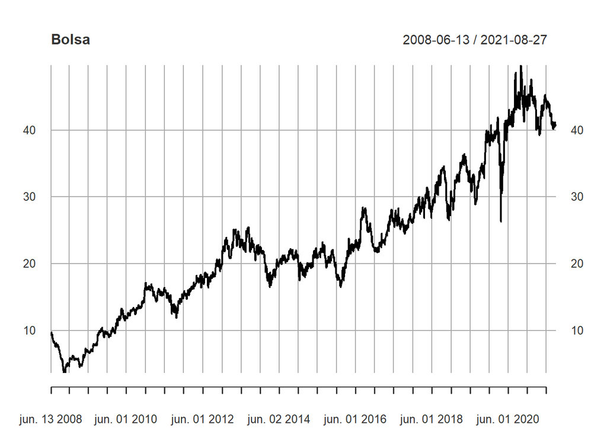

## **Conclusión**

**Los riesgos implicados en este activo, que logramos identificar, son:**

- Riesgo político: Las regulaciones que impone Secretaría de Hacienda y Crédito Público ante ellos
- Riesgo de mercado: Las empresas enlistadas, dejen de operar.
- Riesgo operativo: La plataforma deja de operar por algún problema técnico.
- Riesgo sistemático: El riesgo sistematico esta implicito en todos los activos independientemente de sus caracteristicas

# Segunda Entrega

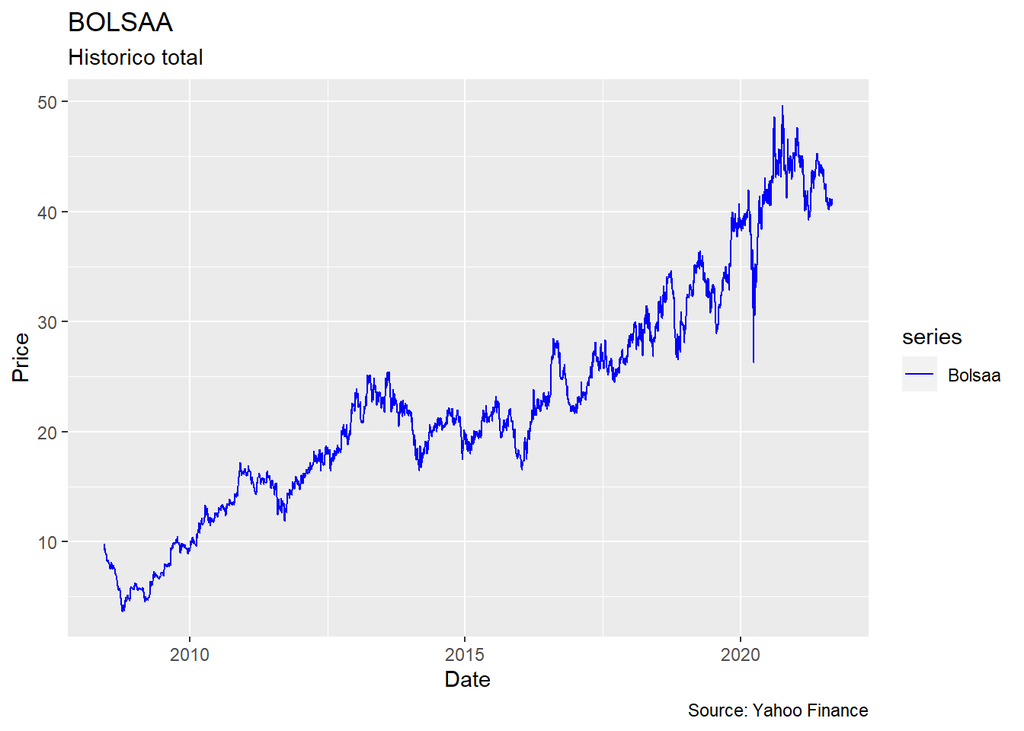

[figure not shown]

[figure not shown]

```r
stock_series
```

Vemos claramente que en el 2020 hay una gran caída en el precio del activo, y esto es obviamente por la crisis economica ocasionada por la pandemia del covid-19, hubo un desplome en las bolsas mundiales, y la Bolsa Mexicana de Valores no fue la excepción, la gente ante la incertidumbre sacaba su dinero de las inversiones por lo que el activo como tal BOLSAA tuvo una evidente caída.

En julio del 2019, se ve una caída en el precio, esto porque gracias a información de [Investing](https://mx.investing.com/news/stock-market-news/las-bolsas-de-valores-de-mexico-cerraron-con-caidas-el-spbmv-ipc-perdio-un-055-1899903), recopilamos que por los retrocesos en los sectores materiales, de servicios financieros y servicios de telecomunicaión impulsaron la baja en el precio de este activo.

Y también se ve reflejada la caída ocasionada por la crisis del 2008, la de las hipotecas en Estados Unidos pero que claramente afectó este activo.

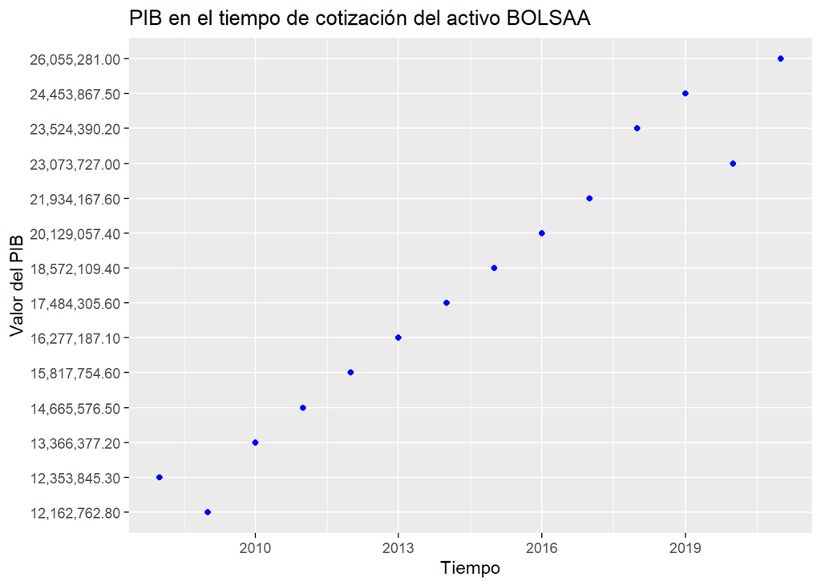

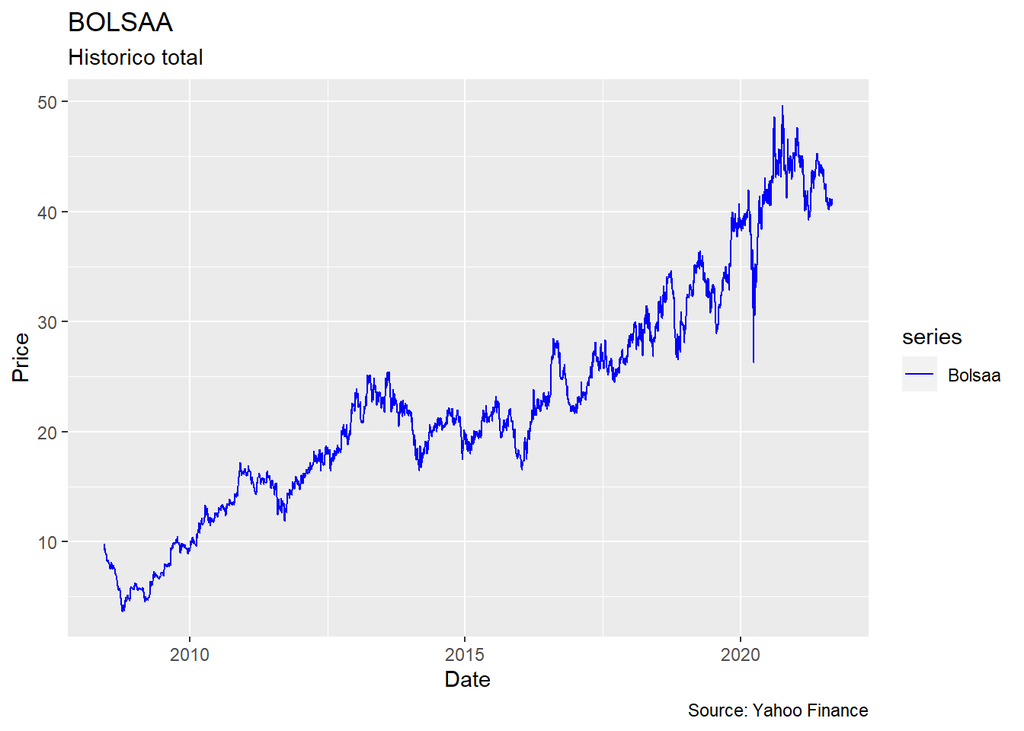

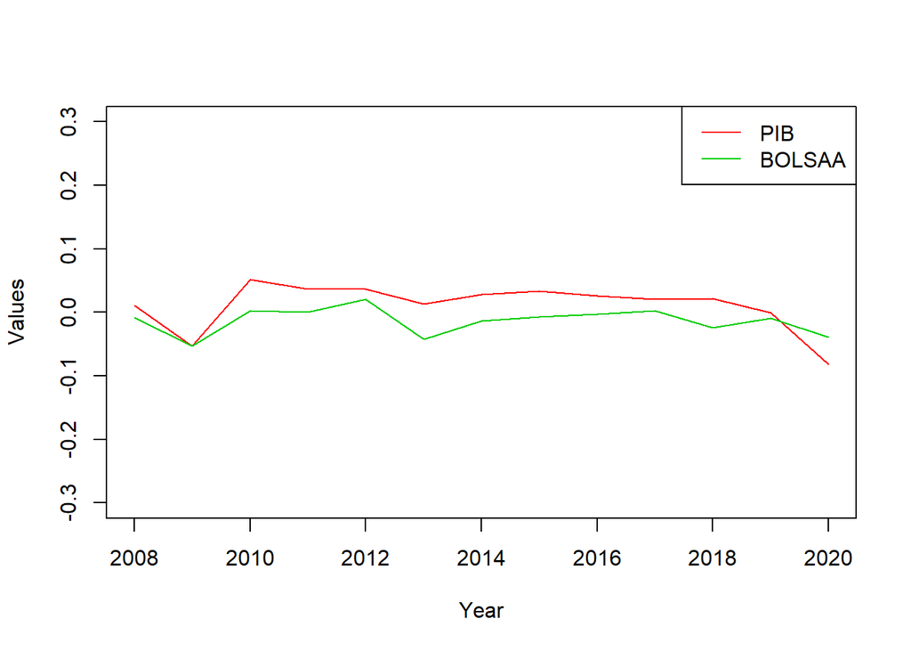

Aquí podemos observar la comparativa dentro de la gráfica y la gran similitud que tuvieron en los cambios durante la última época, podríamos suponer que tienen una correlación bastante alta.

### Situación Actual

Tras el análisis en esta segunda entrega pudimos darnos cuenta de factores que fueron importantes en los picos presentados durante el último año que definieron el comportamiento del activo, parece ser que los más importantes fueron los siguientes:

- Al analizar la gráfica, de forma general podemos hablar de que el activo en cuestión ha tenido un comportamiento negativo durante lo que llevamos del año, con un comportamiento entre 40 y 50 pesos aproximadamente y con caídas y subidas repentinas durante el año
- Durante el último año, parece ser que por los precios bajos, las 15 empresas más grandes han estado recomprando sus propias acciones, lo que significa una reducción en el flujo de compra/venta de activos dentro de la Bolsa Mexicana de Valores lo que impacta en las ganancias del activo. [El ceo](https://elceo.com/mercados/wall-street-8-septiembre-2021-bmv/)
- Tuvimos una subida en el precio del activo en agosto 2020 que al parecer fue porque la BMV rompió máximos históricos con en su cotización lo cual influye positivamente en el comportamiento del activo. [Sentido Común](https://www.sentidocomun.com.mx/articulo.phtml?id=99740)
- Luego ocurrió una bajada en el precio del activo entre la 2da y 3er semana de octubre 2020 que, tras presentar su reporte del 3er trimestre del año, tuvo una bajada de casi 7% en el rango de tiempo ya mencionado, a pesar de su alza en ingresos (3%) y flujo operativo (4%), pero con una utilidad neta inferior (6%) que parece ser lo que mandó a la baja el precio de la acción. Aunque fue rápidamente recuperado el precio, prácticamente a como estaba en menos de una semana. [El ceo](https://elceo.com/mercados/bolsa-mexicana-valores-reporte-3t20-acciones/)
- Existió después una caía fuerte y prolongada en el tiempo desde finales de diciembre a inicios de marzo del 2021, desde casi 50 pesos por acción hasta los 41, parece ser que son diversas razones entre las cuales se encontraba la incertidumbre sobre un nuevo paquete de estímulos fiscales por parte del gobierno americano por 1,900 MDD, que tenía a inversionistas cautelosos, además de la misma pandemia y la baja de precios en las acciones del índice, donde 31 de las 35 empresas operaban con pérdidas. [América economía](https://www.americaeconomia.com/economia-mercados/bolsa/bolsas-en-mexico-operan-en-rojo-por-contagio-de-covid-de-carlos-slim)
- Desde inicios de marzo se observa una recuperación en el precio de la acción de Grupo BMV o BOLSAA, esto es dado al precio tan bajo que se tenía, por esto el mismo grupo decidió comenzar a recomprar sus propias acciones “en descuento” y así también fortalecerla confianza en los inversionistas y crear una ola de compra que elevaría aún más el precio, dicho y hecho. [El financiero](https://www.elfinanciero.com.mx/mercados/la-bolsa-mexicana-comprara-acciones-propias-a-partir-del-1-de-marzo/)

## **Referencias**

- Investing (2021). Enlace: https://mx.investing.com/equities/bolsa-mexicana-de-valores-a
- GBM (2021). Enlace: https://plus.gbm.com/index.html
- Factset (2021). Enlace: https://my.apps.factset.com/navigator/company-security/snapshot/BOLSAA-MX

# Tercera Entrega —-

**1) Calculamos el rendimiento y la volatilidad anual**

**Información del Activo**

| RenD | RenA | VolD | VolA |
| --- | --- | --- | --- |
| 0.0002229 | 0.0561654 | 0.0195193 | 0.3098598 |

Calculamos los rendimientos Diarios y Anuales asi como la volatilidad a partir de los historicos del activo de BOLSAA.MX

**2)Prueba de normalidad**

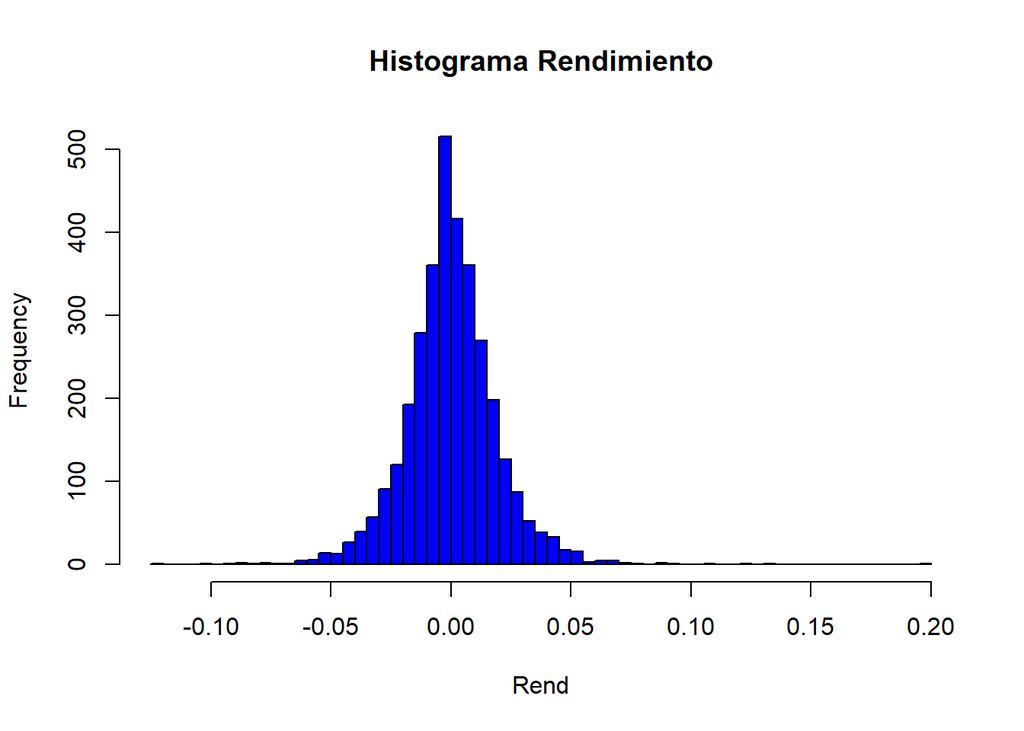

$H_0$: Normalidad en la variable $H_a$: No hay normalidad en la variable

```
##
##  Jarque-Bera Normality Test
##
## data:  as.numeric(Rend)
## JB = 5583.9, p-value < 2.2e-16
## alternative hypothesis: greater
```

Para nuestro activo de BOLSAA.MX decimos que es necesario rechazar $H_0$, concluimos que los datos no son normales.

```
##       JB
## 5583.888
```

No hay normalidad porque el JB es de 5583.888135.

### Prueba de rendimiento cero

La media de los rendimientos diarios es muy pequeña, por lo que haremos una prueba de hipótesis para determinar si es o no estadísticamente igual a cero.

$H_0$: La media de la variable es cero $H_a$: La media de la variable es diferente de cero

Criterio de decisión. Si el estadístico es mayor a 2.3295 rechazamos $H_0$.

```
##         t
## 0.6627565
```

Como el estadístico es 0.6627565, no rechazamos nuestra hipótesis nula, por lo que la media de los rendimientos de BOLSAA.mx es cero.

## Ecuación ds para el periodo 2020

Usemos los datos del 2020, para construir la ecuación ds que describe el comportamiento del precio
$$dS=\mu*S*dt+\sigma*S*dW$$

Hcemos la simulación para 10, 20 y 40 días

95% de confianza

| LimiteInf_10D | LimiteSUp_10D | LimiteInf_20D | LimiteSUp_20D | LimiteInf_40D | LimiteSUp_40D |
| --- | --- | --- | --- | --- | --- |
| 39.48973 | 57.23864 | 36.02533 | 61.12608 | 31.25701 | 66.75484 |

#### Ahora con lnSt —-

95% de confianza

| LimiteInf_3M | LimiteSUp_3M | LimiteInf_6M | LimiteSUp_6M | LimiteInf_9M | LimiteSUp_9M | LimiteInf_12M | LimiteSUp_12M |
| --- | --- | --- | --- | --- | --- | --- | --- |
| 43.41293 | 53.04634 | 41.48181 | 55.10551 | 40.01563 | 56.70119 | 38.79012 | 58.05694 |

#### Discusión sobre lo que dice la teoría en relación con la normalidad y las implicaciones del modelo teórico sobre los datos reales. —-

Aquí vemos que en la teoría si aplicó a la realidad, claro que hay un desfase en el precio esperado, bien sabemos que no podemos ver el futuro, pero nos ha sorprendido que si se mantiene dentro del intervalo de confianza, para todos los casos y le vemos una gran utilidad a estos métodos de predicción

# Cuarta Entrega —–

Calculamos los rendimientos diarios, con la diferencia logaritmica entre los pecios del activo en el cierre ajustado

Mostramos la gráfica de la correlación

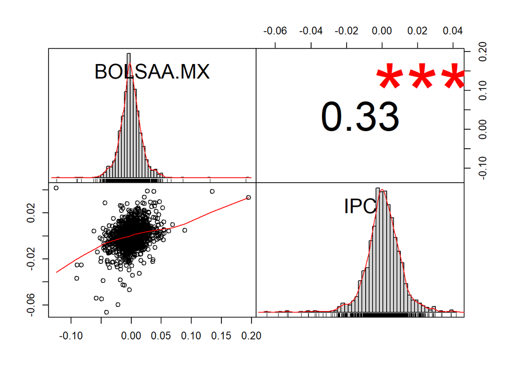

Descargamos la información de todos los activos que cotizan en BMV, para poder compararlos vs nuestro activo de estudio

```r
Emisoras <- Emisoras %>%
  filter(
    EMISORA!='ELEMENT.MX',
    EMISORA!='PAPPEL.MX'
  )
```

mostramos aquellos que tienen mayor correlación vs BOLSAA

```
##              V1        V2
## 2           AMX 0.2861562
## 3         RA.MX 0.2724956
## 4   SITESB-1.MX 0.2723010
## 5   GFINBURO.MX 0.2481981
## 6 LACOMERUBC.MX 0.2414868
```

Encontramos que los activos con mayor correlación son los siguientes:

Regional SA de Cv (Ra.mx): Con sede en San Pedro en Nuevo León, BanRegio Grupo Financiero es una institución dedicada al desarrollo y comercialización de productos financieros.

América Móvil (Amx.mx) Es una empresa multinacional mexicana de telecomunicaciones con sede en la Ciudad de México, México. Tiene presencia en 18 países en América y 8 en Europa, con más de 277 millones de usuarios.

Telesites (Sitesb-1.mx) Es una empresa mexicana dedicada a construir, instalar, mantener, operar y comercializar diversos tipos de sitios –torres y estructuras de soporte, así como espacios físicos y demás elementos no electrónicos, para la instalación de redes de servicios para el sector de telecomunicaciones.

Grupo financiero Inbursa (Gfinburo.mx) Es una sociedad financiera que, a través de sus subsidiarias, proporciona servicios de banca y servicios relacionados en México. La empresa cuenta con líneas de operaciones en fondos de inversión, seguros generales, seguros de automóviles, hipotecas, seguro de salud, fondos de jubilación y banca comercial.

```
## pausing 1 second between requests for more than 5 symbols
## pausing 1 second between requests for more than 5 symbols
## pausing 1 second between requests for more than 5 symbols
```

```
## [1] "BOLSAA.MX"   "RA.MX"       "AMX"         "SITESB-1.MX" "GFINBURO.MX"
## [6] "GFNORTEO.MX" "^MXX"
```

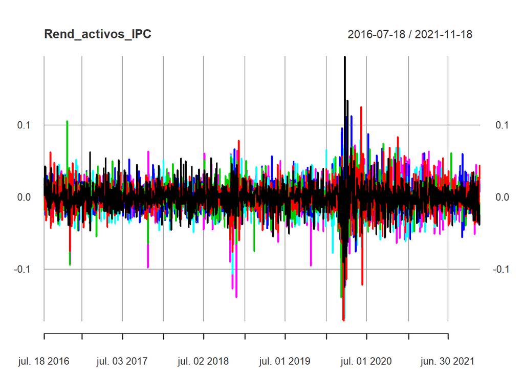

Para una mejor visualización, los proyectaremos en individual.

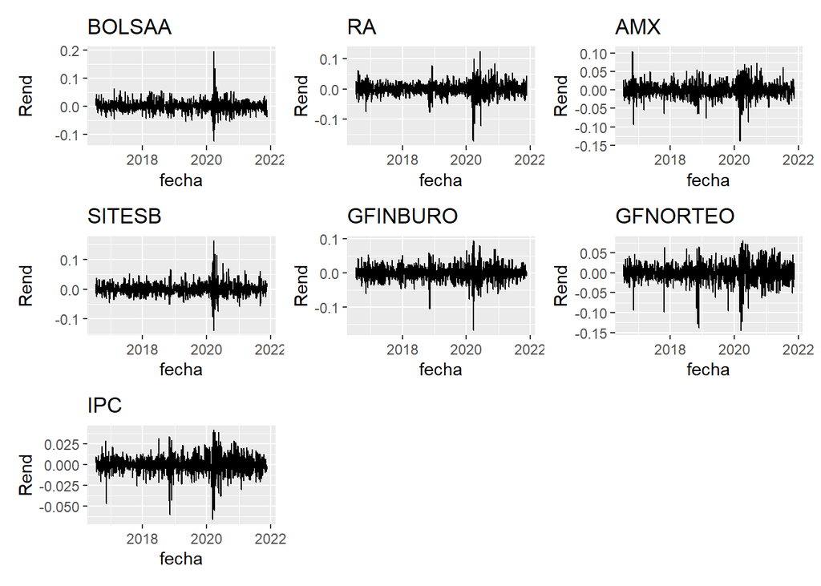

# Quinta entrega :)

Se comenzó eligiendo el activo de menor correlación para esto se utilizó el criterio de correlación, a través de éste pudimos encontrar el activo con la menor correlación posible esto con función de poder diversificar de mejor forma nuestro riesgo a la hora de construir el porafolio

EL Activo resultante fue: Grupo Simec, S.A.B. de C.V. (‘SIMECB.MX’)

[Simec](https://www.emis.com/) es una mini-acería fabricante de productos de acero no planos con una amplia gama de perfiles estructurales, comerciales, varilla y aceros especiales, que se emplean principalmente en los sectores de la construcción, automotriz y manufactura.

Se procedió a hacer la descarga de los datos de ambos activos para los últimos 5 años aproximadamente

Sacamos los rendimientos de los activos y podemos observar en la 1er gráfica el movimiento de los precios. Además de la distribución de los rendimientos de ambos activos en la 2da gráfica

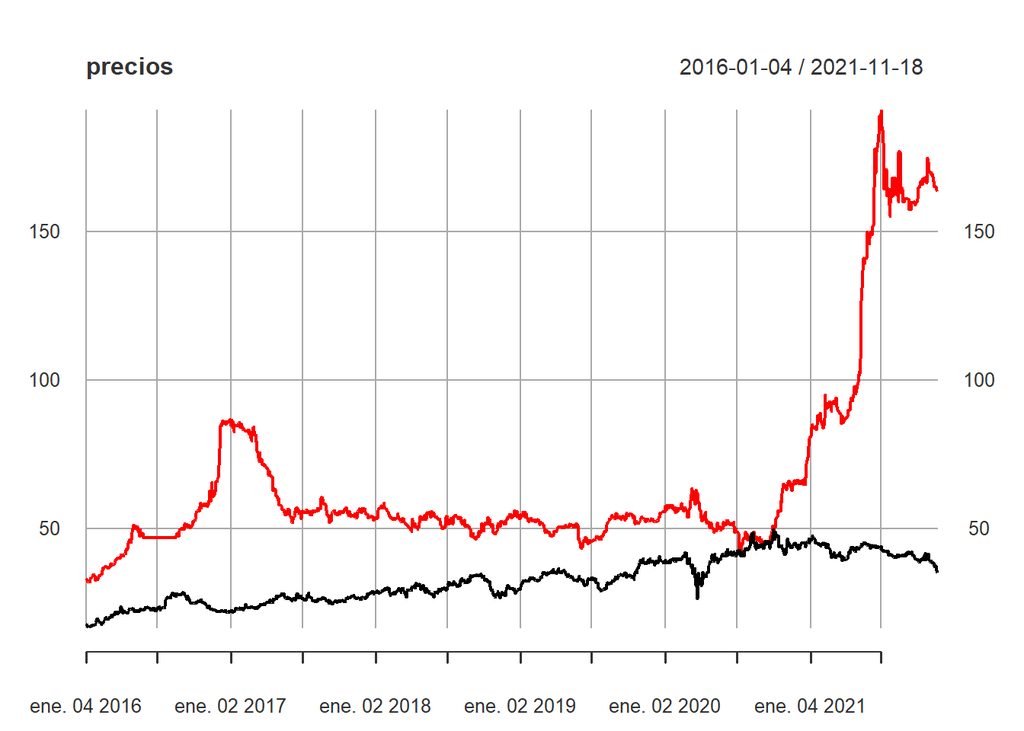

```r
rend1<-na.omit(diff(log(precio)))
rend2<-na.omit(diff(log(precio2)))
rend<-merge.xts(rend1,rend2)
precios<-merge.xts(precio, precio2)
plot(precios)
```

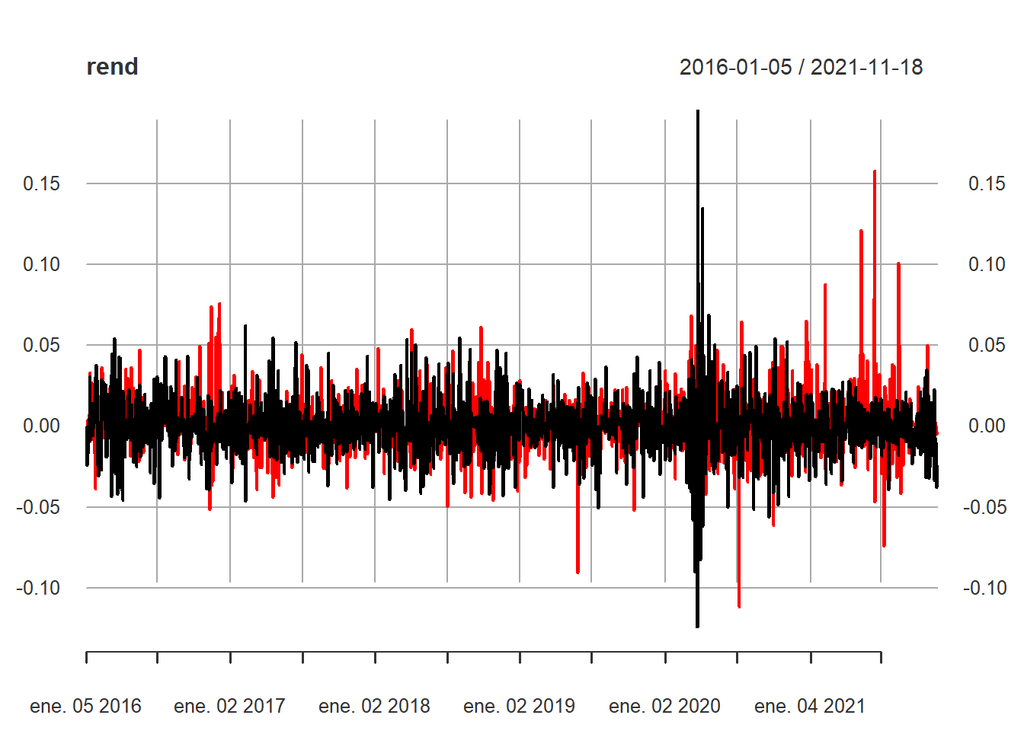

```r
plot(rend)
```

Procedimos a construir un portafolio con ambos activos para determinar su valor inicial. (Al día de hoy)

#### VaR paramétrico

El VaR paramétrico es un método para estimar el Valor en Riesgo, utilizaremos los datos descargados para estimar la rentabilidad diaria, la media y el riesgo (desviación estándar) de cada uno de los activos. A través de la siguiente fórmula lo calcularemos:

VaR = |R – z·δ|· V

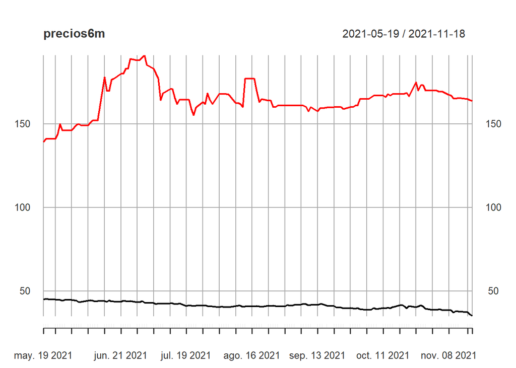

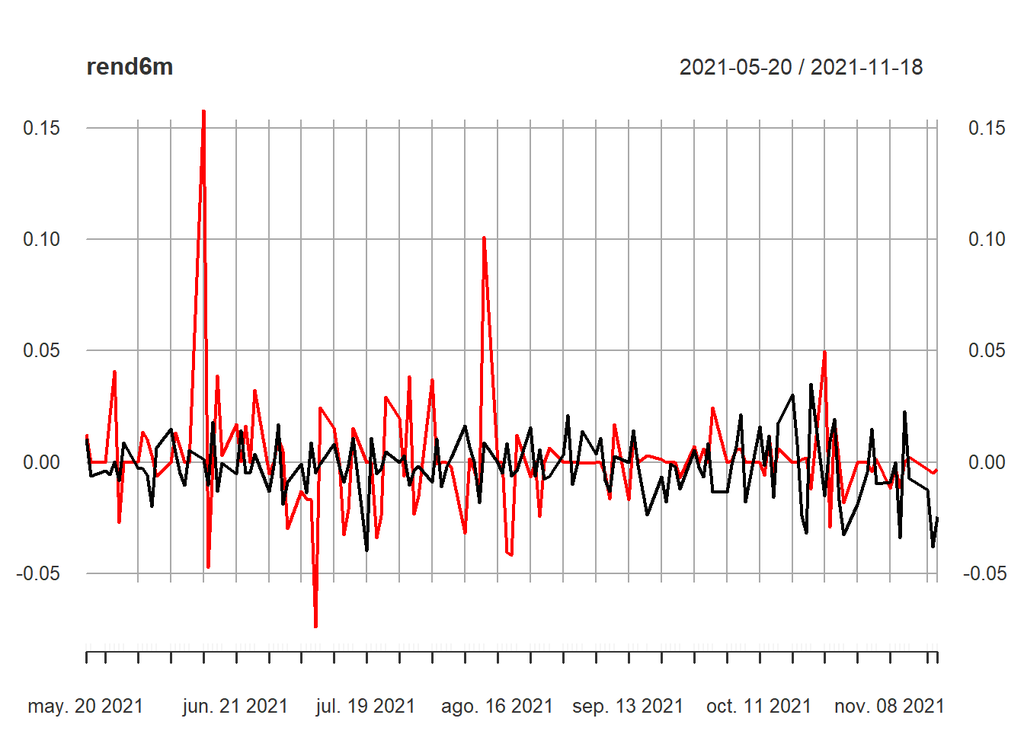

En las gráficas superiores podemos ver los precios y los rendimientos de ambos activos con los últimos 6 meses.

Después procedimos a crear una gráfica de la estimación del valor del portafolio para el siguiente día.

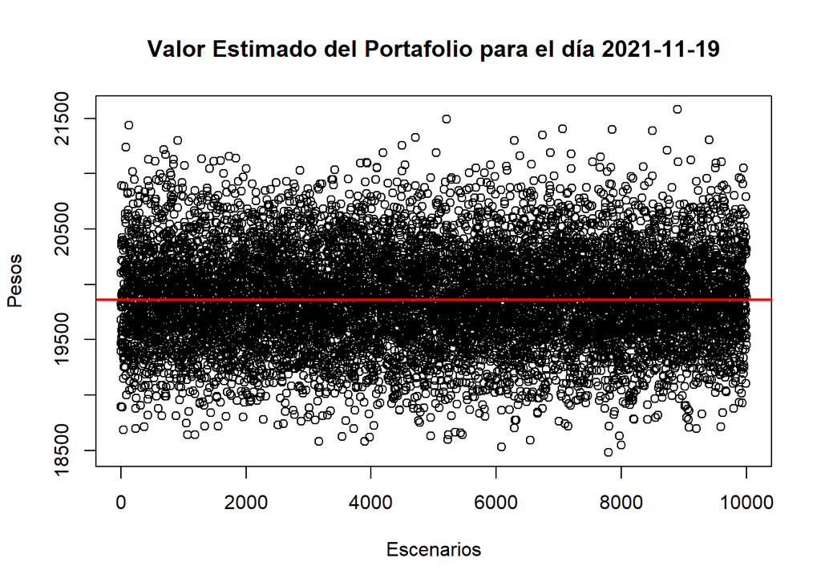

A continuación podemos observar la estimación obtenida de las ganancias o pérdidas previstas por nuestro modelo del VaR para el siguiente día

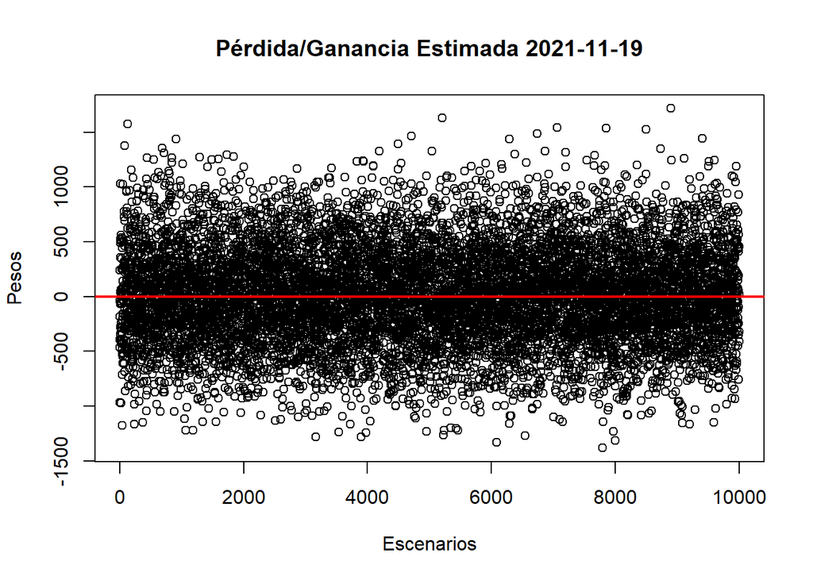

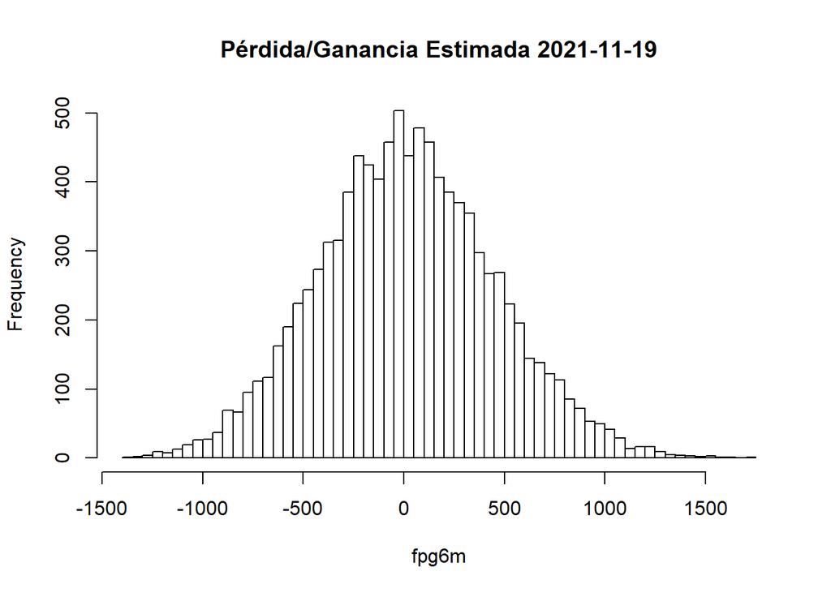

En la grafica observamos la estimación de pérdidas y ganacias donde tenemos una media realmente muy cercana a 0, ni pérdida ni ganancia y la mayor parte de las simulaciones se ubican entre -1500 y 1500. Además agregamos una segunda gráfica con su distribución.

Ahora haremos el cálculo del VaR del portafolio para 1,5,10,20 días cada uno con 90%, 95%, 99% de confianza.

```r
VaR_Total6m
```

```
##            VaR.al.99. VaR.al.95. VaR.al.90.
## 2021-11-19  -954.2749  -693.4918  -537.5922
## 2021-11-24 -2133.8235 -1550.6948 -1202.0926
## 2021-11-29 -3017.6822 -2193.0137 -1700.0157
## 2021-12-09 -4267.6471 -3101.3897 -2404.1852
```

Procederemos a crear un gráfico mostrando el VaR calculado para 1 día con 90%, 95%, 99%

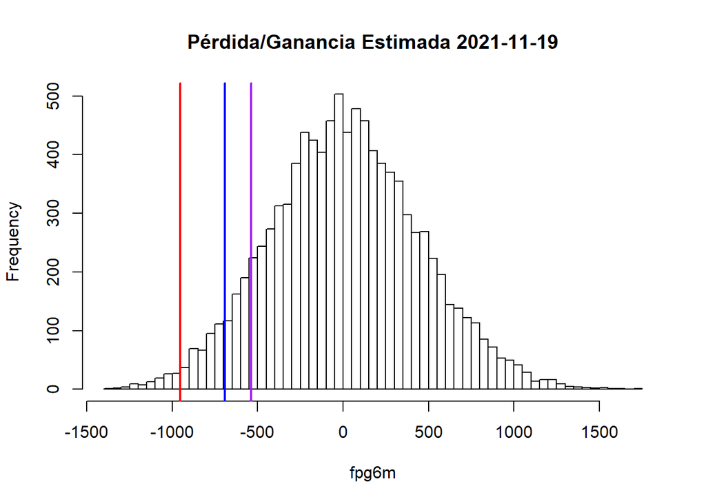

#### Comprobación del VaR mediante un backtesting VAR Paramétrico

Esta técnica se utiliza para comprobar la estimación del VaR. Consiste en analizar el pasado y determinar, el número de dias en los cuales la pérdida real es menor al VaR estimado, para contabilizar las excepciones.

Para ello tendremos los siguientes pasos:

**Paso 1: Construir el valor real del portafolio en el tiempo**

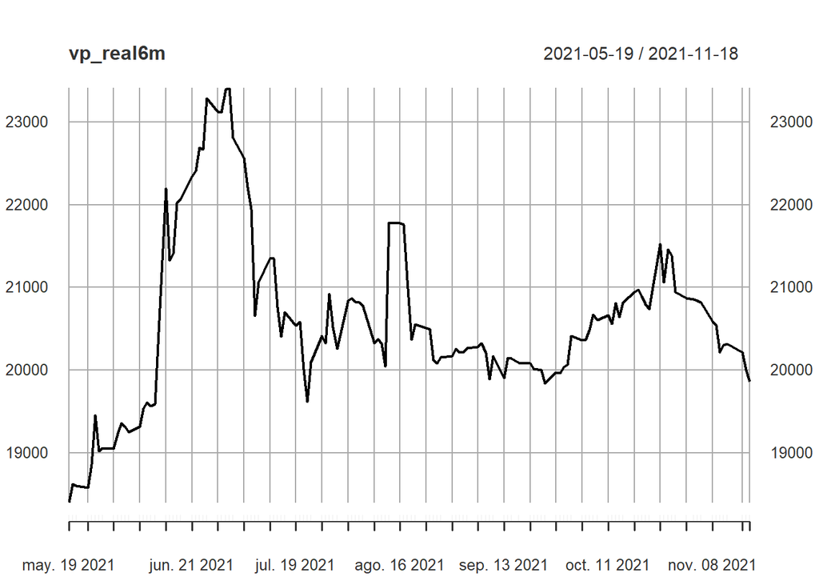

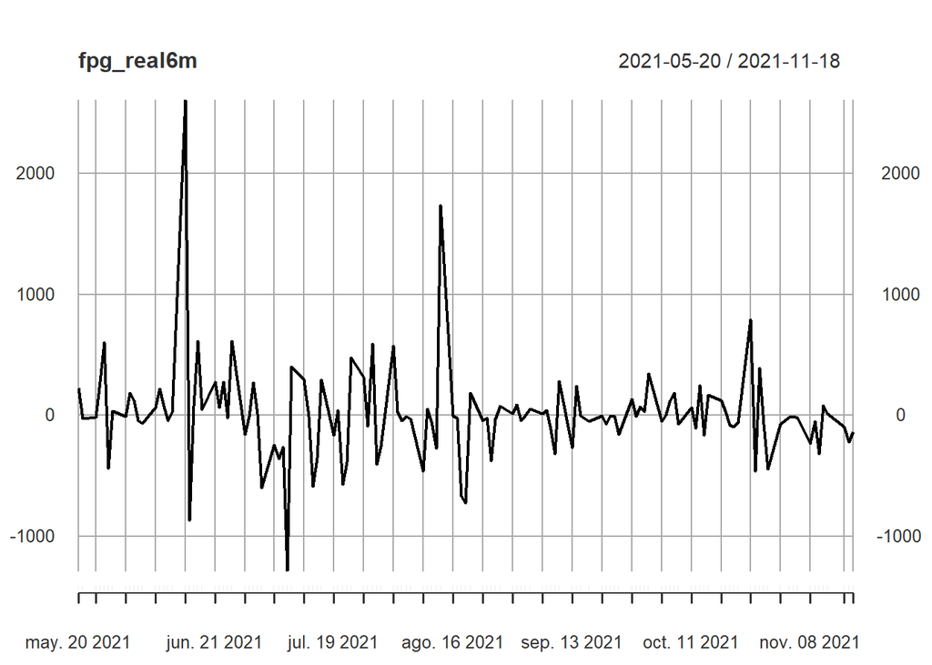

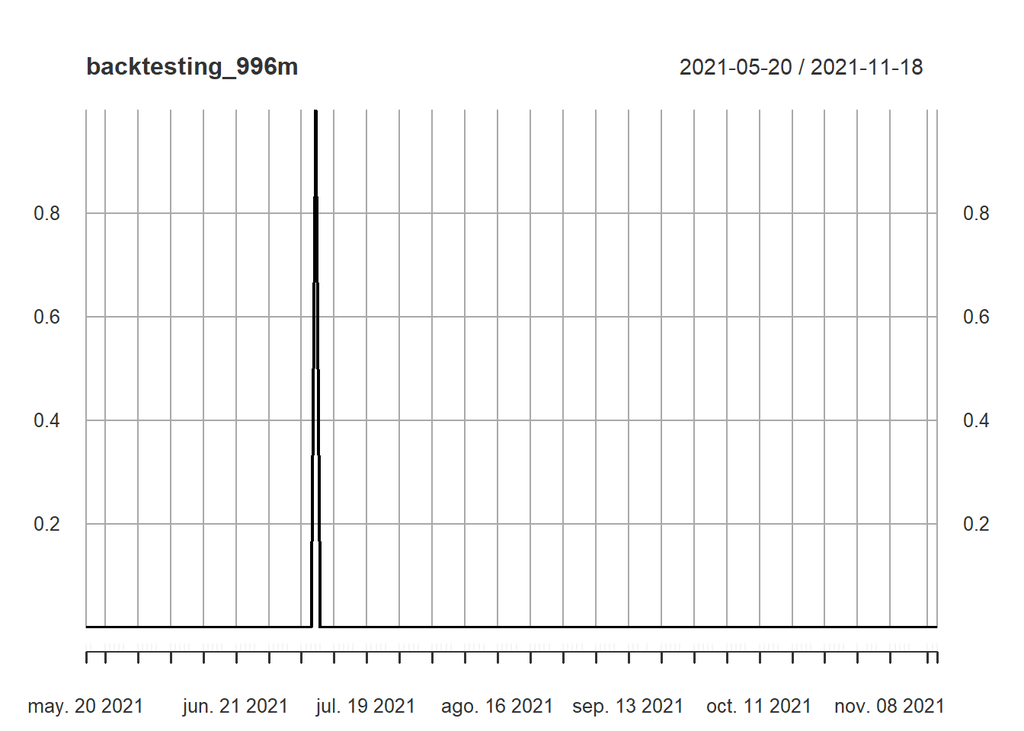

En la gráfica previa se observan en picos donde el VaR superó la estimación y gráficamente sólo se ve 1.

```
## Porcentaje de error 99%:  0.78125
```

```
## , Porcentaje de error 95%:  2.34375
```

```
##  y Porcentaje de error 90%:  5.46875
```

Finalmente en esta tabla ordenamos el backtesting para un día:

```r
back_tabla6m <- data.frame("Test 99%"=back996m, "Test 95%"=back956m, "Test 90%"=back906m, row.names = dia_est6m)
back_tabla6m
```

```
##            Test.99. Test.95. Test.90.
## 2021-11-19  0.78125  2.34375  5.46875
```

### VaR No paramétrico

El VaR no paramétrico no asume normalidad, utiliza los históricos y los proyecta a futuro, así, estimando el VaR para los mísmos días futuros que los pasados.

Después procedimos a crear una gráfica de la estimación del valor del portafolio para el siguiente día.

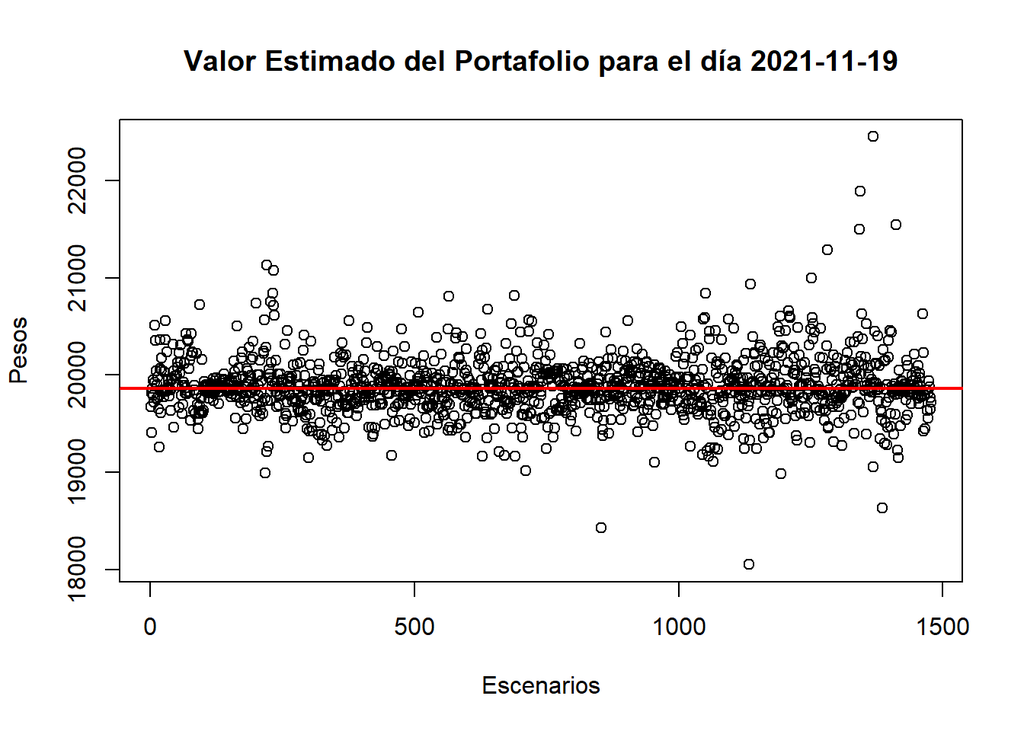

Podemos observar que la mayoría de las simulaciones se ubican entre 18000 y 22000 en la gráfica Con una media de aproximadamente 19800.

A continuación podemos observar la estimación obtenida de las ganancias o pérdidas previstas por nuestro modelo del VaR para el siguiente día

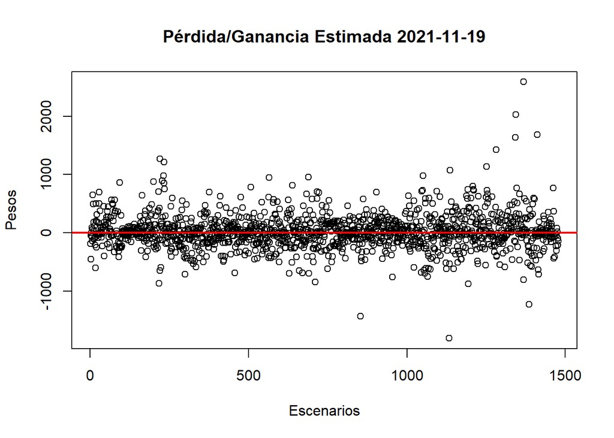

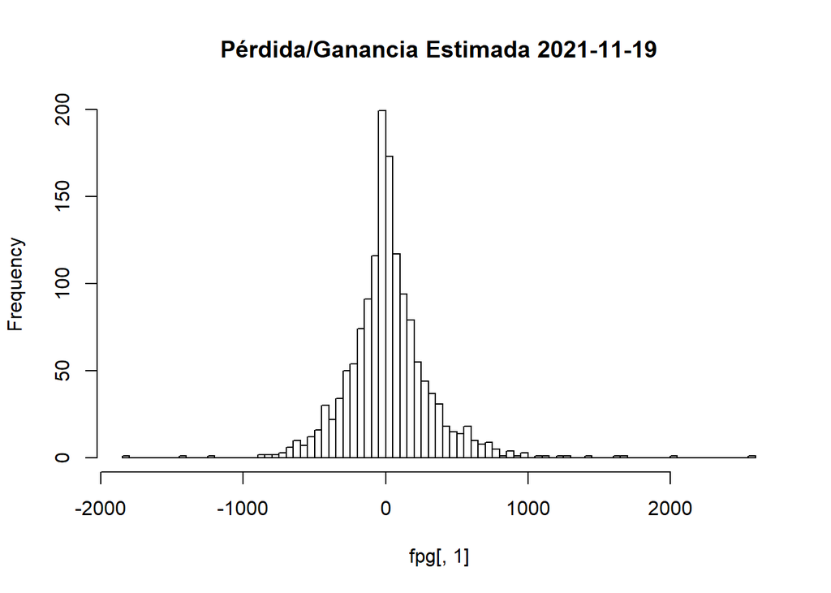

Y ahora en la siguiente tabla, observaremos como son los VaR para 1, 5, 10 y 20 días.

Acomodamos en tabla los VaR con sus respectivos niveles de confianza y días futuros estimados.

```r
VaR_Totalo
```

```
##            VaR.al.99. VaR.al.95. VaR.al.90.
## 2021-11-19  -687.8003  -420.0992  -300.4476
## 2021-11-24 -1537.9682  -939.3704  -671.8212
## 2021-11-29 -2175.0154 -1328.4703  -950.0987
## 2021-12-09 -3075.9363 -1878.7408 -1343.6425
```

#### Comprobación del VaR mediante un backtesting VAR No Paramétrico

Esta técnica se utiliza para comprobar la estimación del VaR. Consiste en analizar el pasado y determinar, el número de dias en los cuales la pérdida real es menor al VaR estimado, para contabilizar las excepciones.

Para ello tendremos los siguientes pasos:

**Paso 1: Construir el valor real del portafolio en el tiempo**

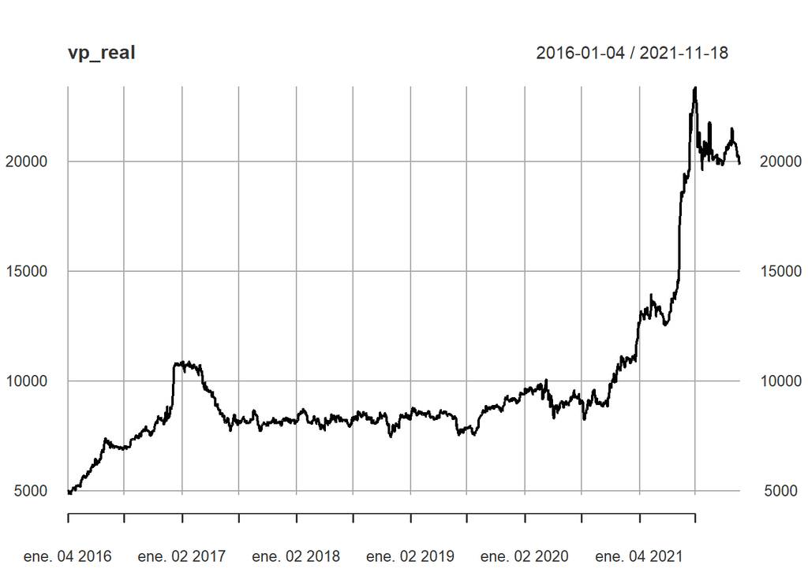

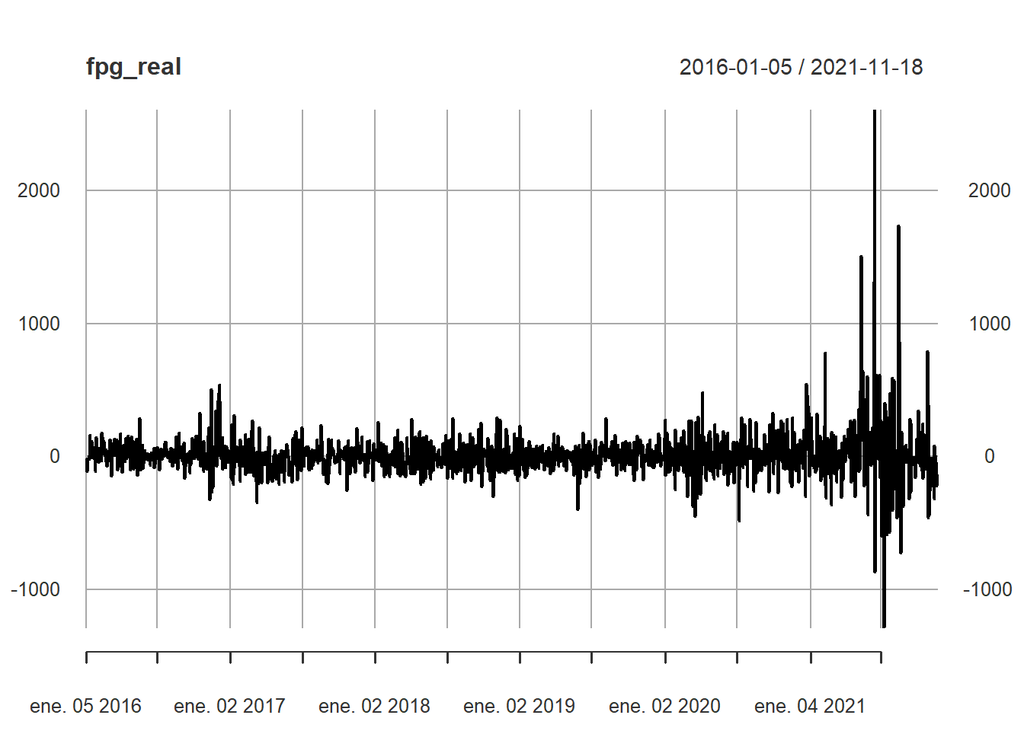

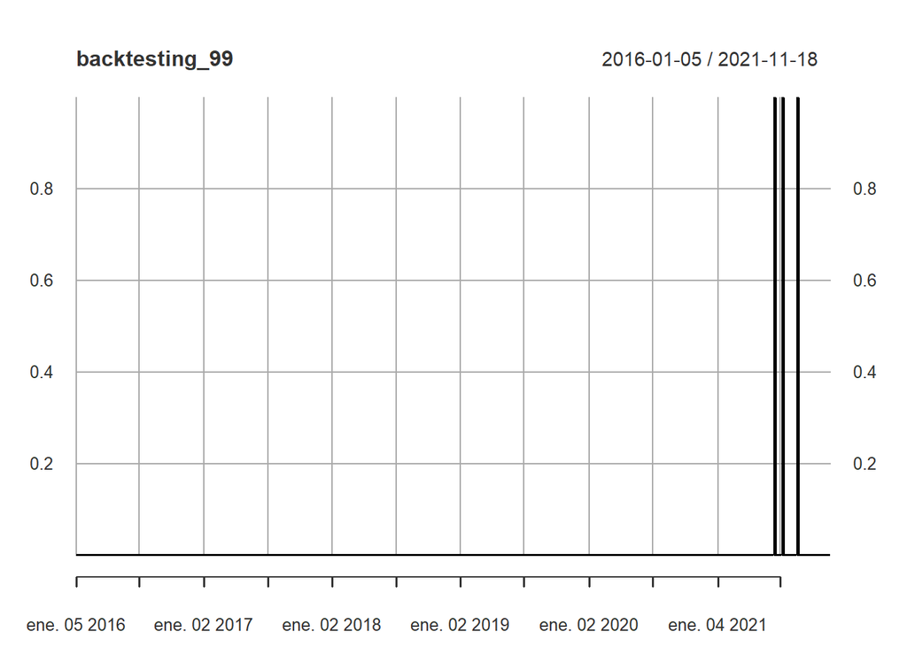

Aquí se ven un poco más de irregularidades con las proyecciones, pero realmente son pocas.

```
## Porcentaje de error 99%:  0.202977
```

```
## , Porcentaje de error 95%:  0.879567
```

```
##  y Porcentaje de error 90%:  2.097429
```

Se raliza el backtesting y podemos observar que nuestra medición es bastante buena, fallando para el 99% solo el 0.2% de las veces y para el 90% solo el 2% de las veces por tanto podemos afrmar que nuetro test es satisfactorio, y nuestra medida de var es correcta

```r
back_tabla <- data.frame("Test 99%"=back99, "Test 95%"=back95, "Test 90%"=back90, row.names = dia_est)
back_tabla
```

```
##            Test.99. Test.95. Test.90.
## 2021-11-19 0.202977 0.879567 2.097429
```

Ponderaciónes de los activos

```r
# Correlación de los activos: -0.01458363
w1 <- (2*vol_2^2-2*-0.01458363)/(2*vol_1^2-4*-0.01458363    + 2*vol_2^2)
w2 <- 1-w1
w1
```

```
## [1] 0.4992515
```

```r
w2
```

```
## [1] 0.5007485
```

Para los activos descritos Bolsa y SIMECB si tuvieramos un portafolio la ponderación adecuada para reducir la minima varianza es de 49.9% para bolsa y 50.1% para SIMECB

# Conclusión:

Con la ayuda del VaR podemos tener conocimiento de cuánto es el máximo valor posible de párdida de nuestro portafolio para diferentes periodos de tiempo. Nos da una información vital a la hora de adquirir cierta acción o portafolio. Nos parecen ambas metodologías útiles, aunque da menor nivel de error en el backtesting el VaR no paramétrico da mejores medidas y estimaciones del VaR. Con todo este proyecto, pudimos analizar los diferente métodos y medidas que nos ayudan a estudiar el riesgo que conlleva adquirir algun activo financiero. Ya sea con suposiciones de normalidad o no. Fue muy interesante estudiar este activo debido a que aprendimos a verlo de otra manera más allá de sálo comprar o vender dependiendo de su gráfica. Ahora tenemos herramientas para elegir de manera óptima los activos de nuestro portafolio, teniendo en cuenta el riesgo que conllevan.

También aprendimos a determinar volatilidades, para uno o mas días con diferentes métodologias. Lo cuál tambien podemos aplicar de ahora en adelante, día con día en nuestros portafolios personales.

Juan Pablo Rodriguez Iván Arellano Ruelas Santiago Romero

Muchas Gracias.